# Flu Serology & HAI

**Files:**

- `sound-life_flu_serology_single.csv` — IgG concentrations, per-sample means
- `sound-life_flu_hai_single.csv` — HAI titers, per-sample means
- `sound-life_flu-vaccine_antigen_metadata.csv` — vaccine composition per year

**Format:** Long format CSVs — one row per sample × antigen combination **Join key:** `sample.sampleKitGuid`

**Visit structure:** Samples collected at Day 0 (pre-vaccine), Day 7 (~1 week post), Day 90 (~3 months post) for two consecutive flu years per subject. Some subjects also have "Immune Variation" visits (same schedule, no vaccine).

**IgG Serology columns:**

- `msd.antigenName` — short antigen label (e.g. "A/Victoria", "B/Colorado") Panel of 7 antigens: A/Brisbane, A/Hong Kong, A/Michigan, A/Victoria, B/Colorado, B/Phuket, B/Washington
- `msd.antigenSubtype` — H1N1, H3N2, Victoria, Yamagata
- `msd.concMean` — mean IgG concentration across replicates (AU/mL)
- `msd.concPercentCV` — coefficient of variation (QC metric; flag if > 20%)
- `msd.signalMean` — raw MSD signal mean
- `msd.batchID`, `msd.plateID` — batch/plate identifiers for QC

**HAI columns:**

**Subject/sample metadata in serology files** (subset of clinical labs metadata):

- `subject.subjectGuid`, `subject.biologicalSex`, `subject.birthYear`, `subject.ageAtFirstDraw`, `subject.race`, `subject.ethnicity`, `subject.cmv`
- `sample.sampleKitGuid`, `sample.visitName`, `sample.drawYear`, `sample.subjectAgeAtDraw`, `sample.daysSinceFirstVisit`
- `vaccine.year` — flu season year (e.g. "2020-2021")

|  | cohort.cohortGuid | subject.subjectGuid | subject.birthYear | subject.ageAtFirstDraw | subject.ageGroup | subject.biologicalSex | subject.race | subject.ethnicity | subject.cmv | sample.sampleKitGuid | ... | msd.plateID | msd.antigenName | msd.antigenSubtype | msd.antigenFullName | msd.sampleDilution | msd.standardConc | msd.signalMean | msd.signalPercentCV | msd.concMean | msd.concPercentCV |
| --- | --- | --- | --- | --- | --- | --- | --- | --- | --- | --- | --- | --- | --- | --- | --- | --- | --- | --- | --- | --- | --- |
| 0 | BR2 | BR2050 | 1960 | 60 | Older Adult | Male | Caucasian | Non-Hispanic origin | Negative | KT00637 | ... | MSD-00031_P1 | A/Hong Kong | H3N2 | A/Hong Kong/2671/2019 (H3N2)-like virus | 10000.0 | NaN | 371.0 | 1.793087 | 30.096199 | 12.519937 |
| 1 | BR1 | BR1028 | 1989 | 31 | Young Adult | Female | Caucasian | Non-Hispanic origin | Negative | KT00628 | ... | MSD-00032_P1 | A/Hong Kong | H3N2 | A/Hong Kong/2671/2019 (H3N2)-like virus | 10000.0 | NaN | 1425.0 | 2.835443 | 490.003120 | 3.523257 |
| 2 | BR1 | BR1003 | 1989 | 30 | Young Adult | Female | Caucasian | Non-Hispanic origin | Negative | KT00643 | ... | MSD-00030_P1 | A/Victoria | H1N1 | A/Victoria/2570/2019 (H1N1) pdm09-like virus | 10000.0 | NaN | 15389.0 | 3.193209 | 5755.555663 | 3.103701 |
| 3 | BR2 | BR2048 | 1963 | 57 | Older Adult | Male | Caucasian | Non-Hispanic origin | Positive | KT02447 | ... | MSD-00069_P1 | A/Michigan | H1N1 | A/Michigan/45/2015 (H1N1)-like virus | 10000.0 | NaN | 182360.0 | 0.384365 | 67916.457990 | 0.386311 |
| 4 | BR2 | BR2002 | 1962 | 57 | Older Adult | Female | Caucasian | Non-Hispanic origin | Positive | KT00021 | ... | MSD-00064_P1 | A/Victoria | H1N1 | A/Victoria/2570/2019 (H1N1) pdm09-like virus | 10000.0 | NaN | 824.0 | 5.765521 | 306.449469 | 6.427630 |

5 rows × 27 columns

| msd.antigenName | sample.sampleKitGuid | A/Brisbane | A/Hong Kong | A/Michigan | A/Victoria | B/Colorado | B/Phuket | B/Washington |
| --- | --- | --- | --- | --- | --- | --- | --- | --- |
| 0 | KT00001 | 2327.356533 | 6910.345676 | 127895.37970 | 1907.391212 | 10926.537490 | 495671.33720 | 6705.177130 |
| 1 | KT00002 | 1911.125338 | 2477.614232 | 62014.82254 | 4950.629958 | 7613.331384 | 52824.45465 | 5354.211493 |
| 2 | KT00003 | 575.481973 | 5745.338298 | 30991.93971 | 2149.894449 | 28080.870010 | 185081.38260 | 25467.273110 |
| 3 | KT00004 | 632.716966 | 1349.099724 | 29168.41079 | 1552.405973 | 3048.322962 | 129781.83760 | 2131.936957 |
| 4 | KT00006 | 2403.628517 | 1258.122225 | 113438.02050 | 9438.043828 | 12834.605270 | 243411.69900 | 7351.420998 |

|  | cohort.cohortGuid | subject.subjectGuid | subject.birthYear | subject.ageAtFirstDraw | subject.ageGroup | subject.biologicalSex | subject.race | subject.ethnicity | subject.cmv | sample.sampleKitGuid | ... | msd.batchID | msd.plateID | msd.antigenName | msd.antigenSubtype | msd.antigenFullName | msd.sampleDilution | msd.signalNormMean | msd.signalNormPercentCV | msd.blankNormMean | msd.percentNormInhibition |
| --- | --- | --- | --- | --- | --- | --- | --- | --- | --- | --- | --- | --- | --- | --- | --- | --- | --- | --- | --- | --- | --- |
| 0 | BR1 | BR1044 | 1994 | 26 | Young Adult | Male | Caucasian | Non-Hispanic origin | Positive | KT00511 | ... | PLAN-00144-5 | 2BMACAT013_Batch5_Plate15 | A/Kansas | H3N2 | A/Kansas/14/2017 (H3N2)-like virus | 5000 | 10268.0 | 4.518894 | 15833.5 | 35.150156 |
| 1 | BR1 | BR1006 | 1988 | 31 | Young Adult | Male | Caucasian | Non-Hispanic origin | Negative | KT00017 | ... | PLAN-00144-1 | 2BMACA6053_Batch1_Plate3 | A/Cambodia | H3N2 | A/Cambodia/e0826360/2020 (H3N2)-like virus | 5000 | 5412.5 | 3.427252 | 6905.0 | 21.614772 |
| 2 | BR2 | BR2015 | 1964 | 56 | Older Adult | Female | Caucasian | Non-Hispanic origin | Negative | KT00629 | ... | EXP-01072 | Plate_2BMACAP012 | B/Washington | Victoria | B/Washington/02/2019-like virus (B/Victoria li... | 5000 | 243071.5 | 9.618363 | 598706.0 | 59.400524 |
| 3 | BR1 | BR1028 | 1989 | 31 | Young Adult | Female | Caucasian | Non-Hispanic origin | Negative | KT02541 | ... | PLAN-00144-4 | 2BMACA2024_Batch4_Plate11 | B/Washington | Victoria | B/Washington/02/2019-like virus (B/Victoria li... | 5000 | 418953.0 | 20.394889 | 576071.0 | 27.274069 |
| 4 | BR2 | BR2008 | 1964 | 56 | Older Adult | Female | Caucasian | Non-Hispanic origin | Negative | KT00619 | ... | PLAN-00144-1 | 2BMACA6053_Batch1_Plate3 | B/Washington | Victoria | B/Washington/02/2019-like virus (B/Victoria li... | 5000 | 361300.5 | 10.631732 | 658534.5 | 45.135676 |

5 rows × 26 columns

| msd.antigenName | sample.sampleKitGuid | A/Brisbane | A/Cambodia | A/Guangdong | A/Hong Kong | A/Kansas | A/Phuket | A/Shanghai | A/Wisconsin | B/Washington | BSA |
| --- | --- | --- | --- | --- | --- | --- | --- | --- | --- | --- | --- |
| 0 | KT00001 | 3817.0 | 5346.5 | 31782.5 | 5882.5 | 6422.5 | 195540.5 | 614940.5 | 15777.0 | 504007.5 | 0.0 |
| 1 | KT00002 | 3475.0 | 5427.0 | 37846.5 | 5908.5 | 7076.5 | 593625.5 | 607454.5 | 15676.0 | 387248.0 | 0.0 |
| 2 | KT00003 | 3799.0 | 5391.0 | 40373.0 | 5189.5 | 6031.5 | 457020.0 | 473753.0 | 17973.0 | 425382.5 | 0.0 |
| 3 | KT00004 | 3887.0 | 5737.0 | 38134.0 | 6477.5 | 8167.5 | 444550.5 | 493688.0 | 16696.5 | 663858.0 | 0.0 |
| 4 | KT00006 | 3798.5 | 5546.0 | 25393.0 | 5835.5 | 6918.5 | 334645.0 | 418380.0 | 17067.0 | 547656.0 | 0.0 |

[output not shown]

## Pre-Vaccination Immune Status

Day 0: starting point from which all vaccine responses are measured. Going into vaccination, how immunologically primed is each subject, and does that baseline protection differ between young and older adults?

**IgG**: Immunoglobulin G, the dominant antibody class in blood serum, produced by plasma B cells in response to prior infection or vaccination.IgG antibodies are long-lived memory molecules, often persisting for years or decades, and they represent the immunological record of a person's pathogen exposure history. When you see a high Day 0 IgG level against a particular flu antigen, it means that person's immune system has previously encountered that antigen (either through prior infection with a related strain or through a prior season's flu vaccine).

`msd.concMean`: mean IgG concentration across replicate wells in AU/mL (aribitrary units per milliliter) -- higher msd.concMean means more IgG antibody against that antigen.

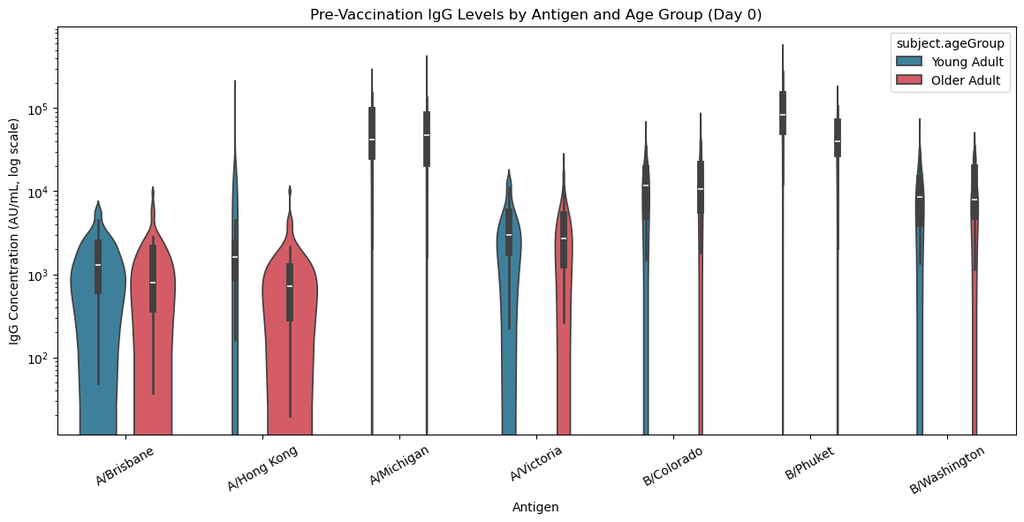

**HAI**: Hemagglutination Inhibition Assay -- gold-standard test for flu vaccine immunity. The assay exploits the biology of flu entry. The flu virus binds to red blood cells via its surface hemagglutinin (HA) protein, causing the cells to agglutinate — clump together in a visible lattice. Antibodies that bind to and block the HA protein prevent this clumping. The HAI assay adds a subject's serum to a mixture of flu virus and red blood cells: the more neutralizing antibodies present, the more the hemagglutination is inhibited.

`msd.percentNormInhibition`: percentage of inhibition relative to an antibody-free negative control:

- 0% means no inhibition: subject's serum has no neutralizing effect on that strain, the virus agglutinates the red blood cells just as freely as in the control well
- 100% means complete inhibition: the antibodies fully block HA binding, no hemagglutination occurs

In traditional HAI assays run as serial dilutions, a titer of 1:40 is the established correlate of seroprotection (roughly 50% reduction in infection risk). The Sound Life assay reports a continuous percentage rather than a discrete titer, which is statistically more tractable but means you cannot directly apply the classical 1:40 threshold without converting.

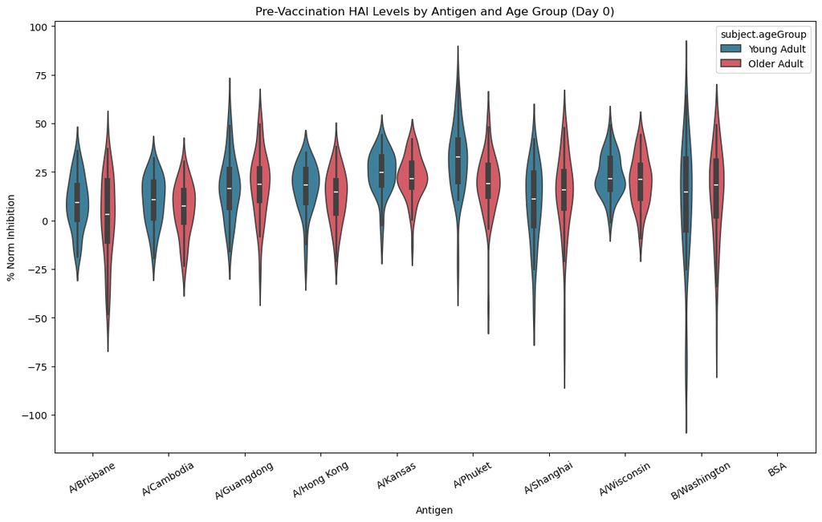

## Vaccine Response Trajectories (Day 0 / 7 / 90)

**Day 0**: pre-vaccination baseline -- height of Day 0 box relative to Day 7 is most important visual relationship.

**Day 7**: peak acute response -- one week post-vaccination, plasma B cells activated by the vaccine are secreting large quantities of IgG, driving concentrations to their highest point, such that the vaccine's immunogenicity is most visible.

**Day 90**: durability checkpoint -- three months post-vaccination, the short-lived plasma B cell response has subsided and what remains reflects longer-lived plasma cells and memory B cells. The Day 90 concentration sitting between Day 0 and Day 7 is the expected pattern — the acute response wanes but ideally doesn't fall all the way back to pre-vaccination levels.

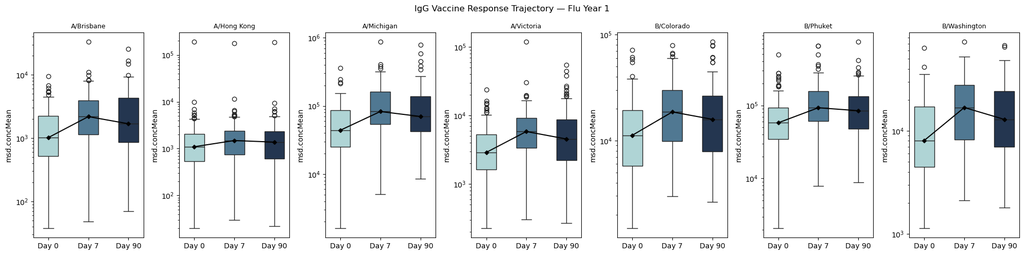

| IgG Response | HAI Response | Interpretation |
| --- | --- | --- |
| Strong rise | Strong rise | Vaccine induced abundant, highly functional antibodies |
| Strong rise | Weak rise | Abundant antibodies but poor quality — binding non-neutralizing epitopes |
| Weak rise | Strong rise | Few antibodies but highly potent — efficient neutralizers |
| Weak rise | Weak rise | Poor overall vaccine response |

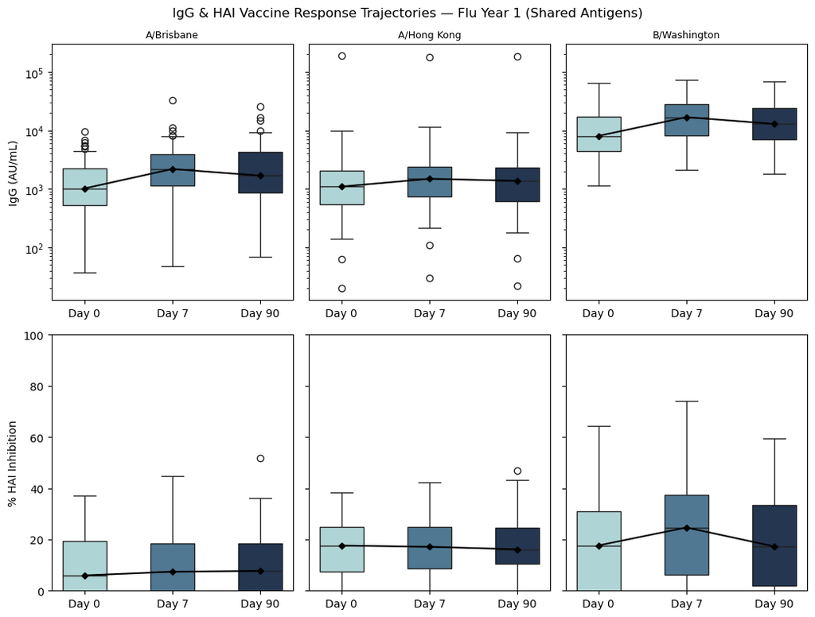

## Fold Change

**Fold Change**: ratio that expresses how much a measurement changes between two conditions relative to the starting value (e.g., per-subject fold change = Day 7 IgG / Day 0 IgG)

Log₂ scale is used so that:

- **0** = no change (fold change = 1; dashed gray line)
- **2** = seroconversion threshold (fold change ≥ 4; dotted red line)
- **Negative values** = antibody concentration fell from Day 0 to Day 7, possible at very high baseline titers due to regression to the mean or assay variation

Fold change is the right outcome variable to use when the Bayesian network makes predictions about vaccine response. The BN will be trained on baseline molecular data (Day 0 clinical labs, proteomics, transcriptomics) and then asked: given this subject's molecular profile at baseline, what vaccine response would you predict? Fold change normalizes out the pre-existing immunity each subject brings in.

| timepoint | subject.subjectGuid | msd.antigenName | subject.ageGroup | subject.cmv | Day 0 | Day 7 | Day 90 | fold_change_d7 | log2_fc_d7 |
| --- | --- | --- | --- | --- | --- | --- | --- | --- | --- |
| 0 | BR1001 | A/Brisbane | Young Adult | Negative | 2327.356533 | 2497.469720 | 2348.607094 | 1.073093 | 0.101775 |
| 1 | BR1001 | A/Hong Kong | Young Adult | Negative | 6910.345676 | 6659.791739 | 6082.022561 | 0.963742 | -0.053281 |
| 2 | BR1001 | A/Michigan | Young Adult | Negative | 127895.379700 | 142380.839900 | 116468.362500 | 1.113260 | 0.154791 |
| 3 | BR1001 | A/Victoria | Young Adult | Negative | 1907.391212 | 4726.948095 | 3123.268946 | 2.478227 | 1.309308 |
| 4 | BR1001 | B/Colorado | Young Adult | Negative | 10926.537490 | 13830.338010 | 11758.447500 | 1.265757 | 0.340000 |

### Fold Change by Age Group

**What to look for:** Whether older adults mount a systematically smaller response (lower log₂ FC median). Mann-Whitney p-values indicate whether age-group differences are statistically significant per antigen. An `ns` antigen is one where age group is not a meaningful predictor of vaccine response — relevant for deciding which BN edges to include.

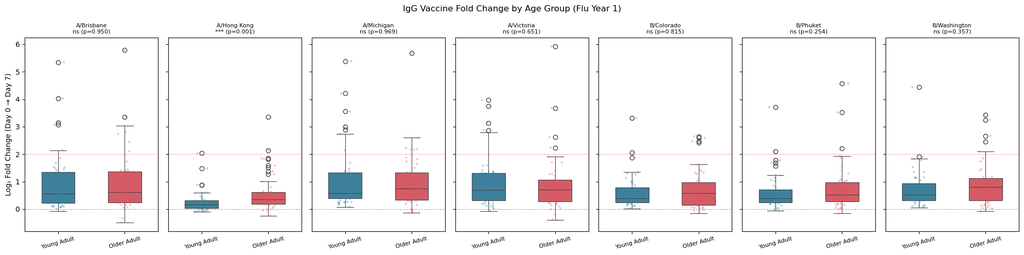

### Fold Change by Age Group × CMV Interaction

CMV serostatus and age are the two strongest drivers of immune aging in this cohort. This panel dissects their interaction: does CMV compound the age-associated decline in vaccine response, or do its effects operate independently?

**What to look for:**

- **CMV+ Older Adults** (bottom-right group in each panel): if this group consistently has the lowest log2 fold change, it confirms that CMV accelerates immune aging on vaccine outcomes
- **CMV+ Young Adults**: CMV-driven immunosenescence can already be detectable in young subjects — compare to CMV− young to see if there is an early phenotype
- **Antigen-specific patterns**: some strains may show stronger age × CMV interaction effects than others, pointing to epitope-specific immune memory differences

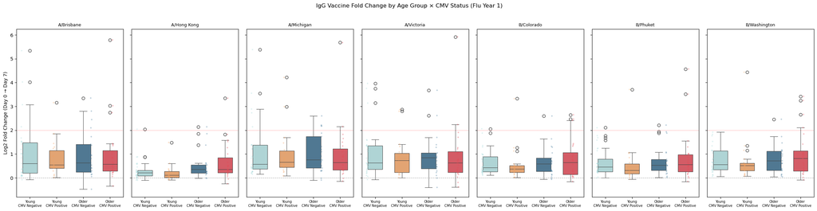

## Age vs. Day 7 IgG (colored by CMV status)

Does continuous age predict vaccine response better than the binary Young/Older split? And does CMV independently shift that relationship? Each panel is one antigen; regression lines are fit per CMV group.

**What to look for:**

- **Negative slope**: a downward trend indicates older subjects generate less IgG — the per-CMV regression line makes this visible across the continuous age range rather than just two bins
- **CMV vertical offset**: if the CMV+ line is consistently lower at any given age, CMV is impacting vaccine response independent of chronological aging
- **Pearson r in legend**: magnitude reflects how well continuous age explains Day 7 IgG. A weak r (near 0) suggests age group alone is insufficient and additional covariates (CMV, baseline IgG, BMI) are needed in the BN
- **Antigen-specific patterns**: some strains may show stronger age slope than others, indicating that age-related immune decline is epitope-specific

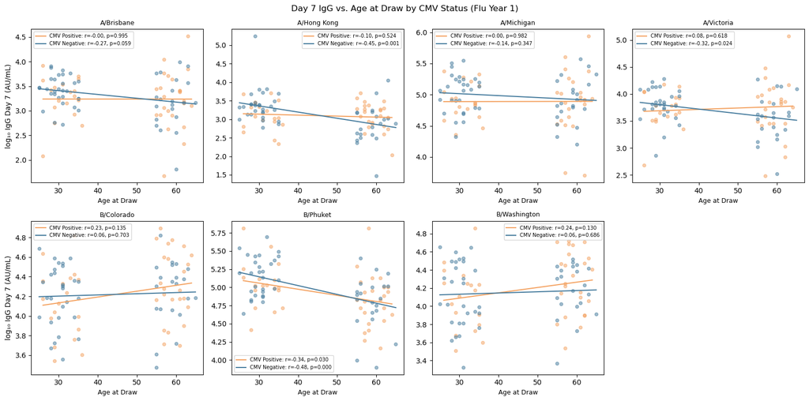

## Seroconversion Rates by Antigen and Age Group

**Seroconversion** = ≥4-fold rise in antibody titer from Day 0 to Day 7. This is the established clinical benchmark for flu vaccine immunogenicity. A population-level rate above ~40% per antigen is generally considered evidence of effective vaccine immunogenicity.

**What to look for:**

- **Young vs. Older gaps**: antigen-specific seroconversion failures in older adults pinpoint where age-related immune decline is most pronounced
- **Antigen variability**: some strains consistently elicit stronger seroconversion — this may reflect better vaccine-strain match or inherently more immunogenic hemagglutinin epitopes
- **Low overall rates**: if most antigens are below 40%, the cohort may have very high pre-existing immunity (high Day 0 titers can suppress fold-change even when Day 7 levels are seroprotective in absolute terms)
- **Implication for BN**: the seroconversion rate per antigen will be the primary validation outcome — predicting which baseline molecular profile leads to seroconversion vs. failure

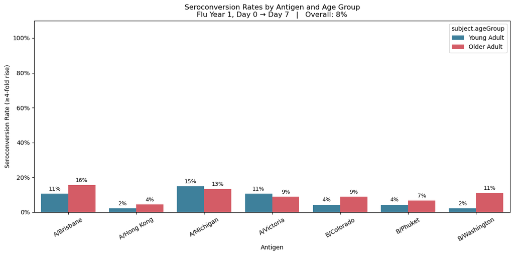

## IgG Waning: Day 7 vs. Day 90

Does the vaccine-induced antibody response persist three months later? Each point is one subject × antigen pair. Points on the dashed diagonal indicate perfect durability; points below the diagonal indicate waning (Day 90 < Day 7).

**What to look for:**

- **Most points below the diagonal**: expected — short-lived plasma cells that drive the Day 7 peak die off by ~3 months, so some drop is universal
- **Age-group differences**: if older adult points lie further below the diagonal (steeper waning), it suggests impaired maintenance of long-lived antibody-secreting cells or poorer memory B cell re-seeding
- **Antigens with severe waning (far below diagonal)**: these will produce low Year 2 Day 0 titers, making Year 2 seroconversion harder — particularly relevant for vaccine efficacy modeling
- **Pearson r**: high r means peak response magnitude predicts durability — subjects who respond more strongly also retain more; low r means durability is decoupled from peak response amplitude

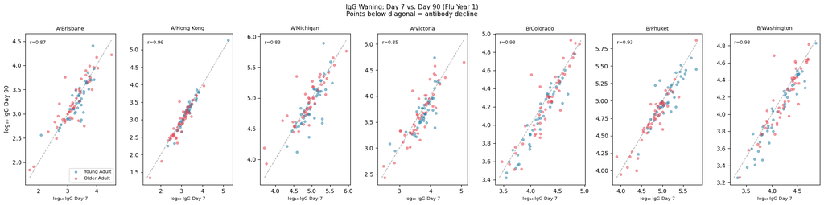

## Cross-Antigen IgG Fold Change Correlation

Are subjects who respond well to one flu strain likely to respond well to others? High cross-antigen correlation points to a **broad responder** phenotype — these individuals mount coordinated immune responses regardless of antigen. Low correlation identifies **narrow responders** who are antigen-specific, which may reflect narrower B cell memory repertoires.

**What to look for:**

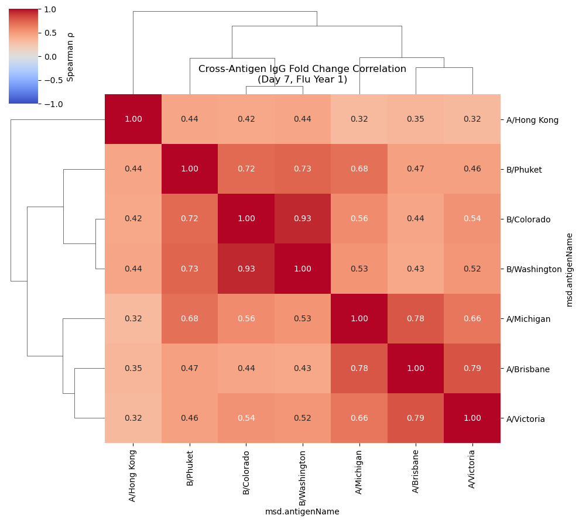

## IgG vs. HAI Concordance (Overlapping Antigens)

IgG concentration measures antibody **quantity**; HAI % inhibition measures antibody **function** (ability to neutralize the virus). These are not the same thing — binding antibodies can target non-neutralizing epitopes and inflate IgG without conferring protection.

**What to look for:**

- **High Pearson r** (r > 0.5): IgG fold change reliably predicts functional neutralization — the two assays are effectively interchangeable for downstream BN use
- **Low r / scatter**: elevated IgG is present but non-neutralizing, likely reflecting antibodies targeting conserved but non-HA epitopes (e.g., neuraminidase or nucleoprotein)
- **Age-group stratification**: if older adult points cluster at high IgG fold change but low HAI inhibition, it suggests aging degrades antibody quality (binding but not neutralizing), not just quantity
- **Note**: the `print()` output will show which antigens share names between the two assays; if the overlap is empty, the naming convention differs between files and a manual mapping is needed

```
Antigens measured by both IgG and HAI: ['A/Brisbane', 'A/Hong Kong', 'B/Washington']
```

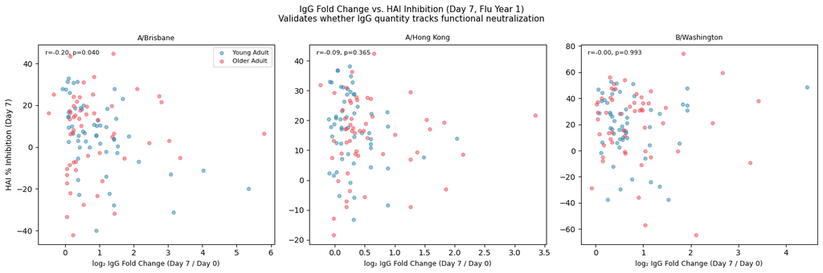

## Year 1 vs. Year 2 Pre-Vaccination Baseline (Day 0)

Year 2 Day 0 is collected ~12 months after Year 1 vaccination. A higher Year 2 Day 0 vs. Year 1 Day 0 means vaccine-induced memory B cells or long-lived plasma cells are still active a year later.

**What to look for:**

- **Year 2 > Year 1 Day 0** (expected): the molecular signature of durable immunological memory from the prior season's vaccination
- **Antigens with no increase**: strains where Year 1 vaccination failed to establish lasting memory, or where pre-existing immunity was already near-maximal (ceiling effect)
- **Magnitude of the shift**: large increases indicate strong priming; modest increases may flag antigens where Year 2 vaccine response will also be weak (already near peak capacity)
- **Implication for the BN**: this is why the baseline table uses Flu Year 1 Day 0 — the Year 1 naïve baseline is cleaner than Year 2, which is confounded by prior vaccination memory

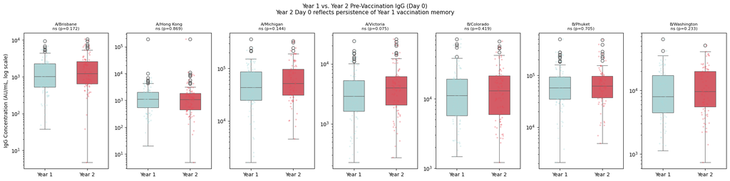